# Adult survival in response to larval acclimation in spongy moth

Sean Powers, PhD and Kristine Grayson, PhD

# 1 Experiment

We were interested in how developmental temperature of spongy moth during the larva stage (caterpillar) and pupa stage impacted survival during the adult stage (moth) when adults are exposed to different temperatures.

Spongy moth eggs from the USDA OTIS laboratory were were hatched and group reared at either 23ºC, 26ºC, or 29ºC (larval acclimation temperature). Larvae (caterpillars) were held in their acclimation treatment until they transitioned to the adult stage (moth). When a larva transitioned to a pupa, it was weighed, placed into a new container by itself, and then placed back into its acclimation temperature. When an adult emerged from its pupa, it was transferred to either 26ºC, 29ºC, 32ºC, or 35ºC (adult exposure temperature). While in its adult exposure temperature, adults were checked twice daily (morning & afternoon) to see if it was alive or dead. Once an adult died, its death date was recorded.

```r
library(tidyverse)
library(gghalves)
library(ggpubr)
library(survival)
library(survminer)
library(ggsurvfit)
library(broom)
library(easystats)
library(MuMIn)
library(patchwork)
library(emmeans)
```

# 2 Experimental data

```r
survival_data <- read_csv('LD OTIS_pupa mass_adult survival_all temps.csv')

survival_data %>% head()
```

```
## # A tibble: 6 × 12
##      id stock_date pupa_date  pupa_mass sex   acc_temp survival_temp emerge_date
##   <dbl> <date>     <date>         <dbl> <chr>    <dbl>         <dbl> <date>
## 1   489 2024-05-03 2024-06-02     0.51  Male        23            26 2024-06-14
## 2   499 2024-05-03 2024-06-02     0.924 Male        23            26 2024-06-15
## 3   503 2024-05-03 2024-06-02     0.65  Male        23            26 2024-06-13
## 4   505 2024-05-03 2024-06-02     0.649 Male        23            26 2024-06-16
## 5   524 2024-05-03 2024-06-03     0.811 Male        23            26 2024-06-17
## 6   530 2024-05-03 2024-06-03     0.88  Male        23            26 2024-06-17
## # ℹ 4 more variables: emerge_TOD <chr>, death_date <date>, death_TOD <chr>,
## #   notes <chr>
```

## 2.1 Column data

1. `id`: individual ID number
2. `stock_date`: date the experiment started and larvae were placed into different treatments
3. `pupa_date`: date a larvae transitioned to a pupa
4. `pupa_mass`: mass of pupa, measured on `pupa_date`
5. `sex`: sex of pupa, determined after enclosion (emergence from pupa)
6. `acc_temp`: larval acclimation temperature measured in ºC
7. `survival_temp`: adult exposure temperature measured in ºC
8. `emerge_date`: date the adult moth emerged from pupa
9. `emerge_TOD`: time of day (AM or PM) the adult moth emerged
10. `death_date`: date an adult moth died
11. `death_TOD`: time of day an adult moth died
12. `notes`: additional notes for an individial

# 3 Exploration of data

First we created a new data frame which included development time (number of days individuals were caterpillars) and survival time (how days an adult moth lived).

```r
total_survival_days <-
  survival_data %>%
  mutate(
    development_time = yday(pupa_date) - yday(stock_date), # development time in days
    adjust_tod = case_when(                                # accounting for the time of day when a pupa
      (emerge_TOD == death_TOD) ~ 0.0,                     # emerged and when it died as a moth
      (emerge_TOD == 'AM' & death_TOD == 'PM') ~ 0.5,
      (emerge_TOD == 'PM' & death_TOD == 'AM') ~ -0.5
    ),
    survival_time = yday(death_date) - yday(emerge_date) + adjust_tod # survival time in days
  ) %>%
  select(id, pupa_mass:survival_temp, development_time, survival_time)

total_survival_days %>% head()
```

```
## # A tibble: 6 × 7
##      id pupa_mass sex   acc_temp survival_temp development_time survival_time
##   <dbl>     <dbl> <chr>    <dbl>         <dbl>            <dbl>         <dbl>
## 1   489     0.51  Male        23            26               30           6
## 2   499     0.924 Male        23            26               30          10
## 3   503     0.65  Male        23            26               30           8.5
## 4   505     0.649 Male        23            26               30           9
## 5   524     0.811 Male        23            26               31          11
## 6   530     0.88  Male        23            26               31          11.5
```

## 3.1 Larval development time

### 3.1.1 Box plots

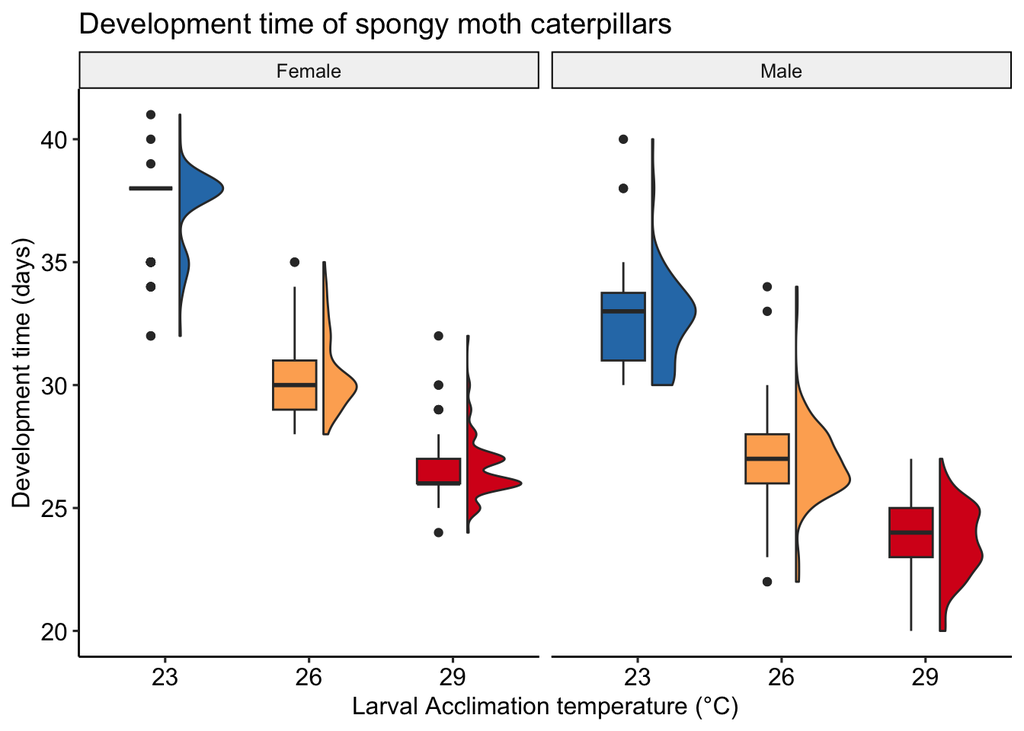

```r
total_survival_days %>%
  select(sex:development_time) %>%
  drop_na() %>%
  ggplot(
    aes(
      x = acc_temp %>% as_factor(),
      y = development_time,
      fill = acc_temp %>% as_factor()
    )
  ) +
  geom_boxplot(
    position = position_nudge(x = -0.1),
    width = 0.3
    ) +
  geom_half_violin(
    side = 'r',
    position = position_nudge(x = 0.1)
    ) +
  labs(
    title = 'Development time of spongy moth caterpillars',
    x = 'Larval Acclimation temperature (°C)',
    y = 'Development time (days)',
  ) +
  facet_wrap(~ sex, ncol = 2)+
  scale_fill_manual(values = c('#2c7bb6', '#fdae61', '#d7191c')) +
  theme_pubr() +
  theme(legend.position = 'none')
```

```r
total_survival_days %>%
  select(id, sex, acc_temp, development_time) %>%
  drop_na() %>%
  group_by(sex, acc_temp) %>%
  summarise(
    n = n(),
    dev_time = mean(development_time),
    st_dev = sd(development_time),
    lower_ci = t.test(development_time, mu = mean(development_time))$conf.int[1],
    upper_ci = t.test(development_time, mu = mean(development_time))$conf.int[2]
    ) %>%
  export_table()
```

```
## sex    | acc_temp |   n | dev_time | st_dev | lower_ci | upper_ci
## -----------------------------------------------------------------
## Female |       23 | 100 |    37.29 |   1.59 |    36.97 |    37.61
## Female |       26 | 125 |    30.37 |   1.50 |    30.10 |    30.63
## Female |       29 |  95 |    26.57 |   1.20 |    26.32 |    26.81
## Male   |       23 |  98 |    32.60 |   1.82 |    32.24 |    32.97
## Male   |       26 | 107 |    26.82 |   1.65 |    26.51 |    27.14
## Male   |       29 | 109 |    23.59 |   1.46 |    23.31 |    23.86
```

Data for development time of spongy moth cateripllars show that development time decreased as larval acclimation temperature increased for both sexes. With males having shorter development times relative to females.

### 3.1.2 Analysis of variance

This was confirmed by an ANOVA that showed the effects of acclimation temperature and sex were significant factors for development time.

```r
dev_time_lm <-
  lm(development_time ~ acc_temp + sex, data = total_survival_days)

dev_time_lm %>%
  anova() %>%
  tidy() %>%
  format_table() %>%
  export_table()
```

```
## term      |  df |    sumsq |   meansq | statistic | p.value
## -----------------------------------------------------------
## acc_temp  |   1 | 10009.75 | 10009.75 |   3352.57 |  < .001
## sex       |   1 |  2110.26 |  2110.26 |    706.79 |  < .001
## Residuals | 631 |  1883.97 |     2.99 |           |
```

## 3.2 Pupal mass

### 3.2.1 Box plots

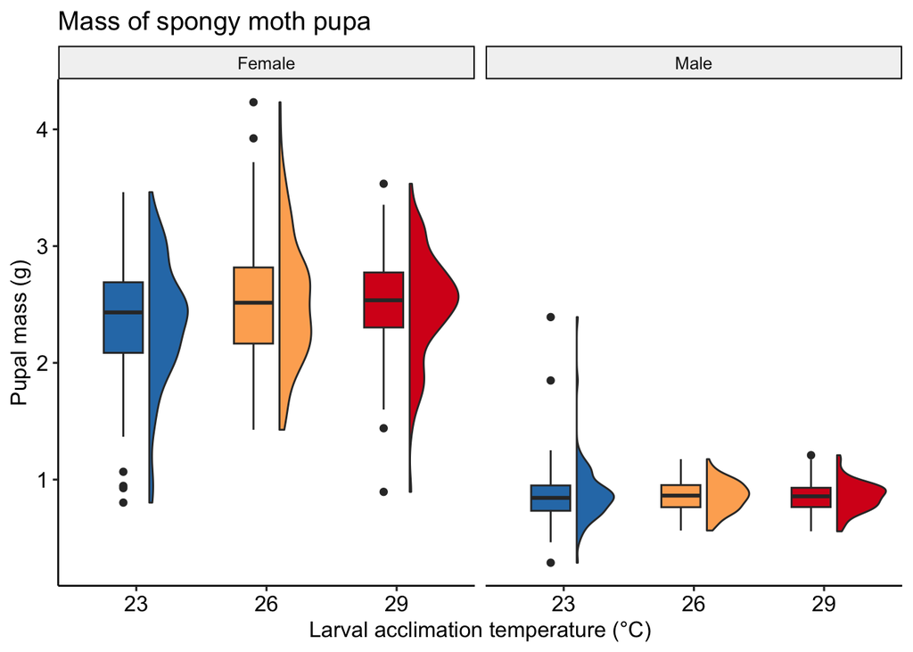

```r
total_survival_days %>%
  select(pupa_mass:acc_temp) %>%
  drop_na() %>%
  ggplot(
    aes(
      x = acc_temp %>% as_factor(),
      y = pupa_mass,
      fill = acc_temp %>% as_factor()
    )
  ) +
  geom_boxplot(
    position = position_nudge(x = -0.1),
    width = 0.3
    ) +
  geom_half_violin(
    side = 'r',
    position = position_nudge(x = 0.1)
    ) +
  labs(
    title = 'Mass of spongy moth pupa',
    x = 'Larval acclimation temperature (°C)',
    y = 'Pupal mass (g)',
  ) +
  facet_wrap(~ sex, ncol = 2)+
  scale_fill_manual(values = c('#2c7bb6', '#fdae61', '#d7191c')) +
  theme_pubr() +
  theme(legend.position = 'none')
```

```r
total_survival_days %>%
  group_by(sex) %>%
  summarise(
    pupal_mass = mean(pupa_mass, na.rm = TRUE),
    st_dev = sd(pupa_mass, na.rm = TRUE)
    ) %>%
  export_table()
```

```
## sex    | pupal_mass | st_dev
## ----------------------------
## Female |       2.46 |   0.51
## Male   |       0.86 |   0.17
```

Box plots show that female pupa were heavier than male pupa and indicate that acclimation temperature had no effect on pupa mass within each sex.

### 3.2.2 Analysis of variance

```r
pmass_lm <-
  lm(pupa_mass ~ acc_temp + sex, data = total_survival_days)

pmass_lm %>%
  anova() %>%
  tidy() %>%
  format_table() %>%
  export_table()
```

```
## term      |  df |    sumsq |   meansq | statistic | p.value
## -----------------------------------------------------------
## acc_temp  |   1 | 1.93e-03 | 1.93e-03 |      0.01 |  0.909
## sex       |   1 |   408.42 |   408.42 |   2767.49 |  < .001
## Residuals | 631 |    93.12 |     0.15 |           |
```

## 3.3 Total days adults survived

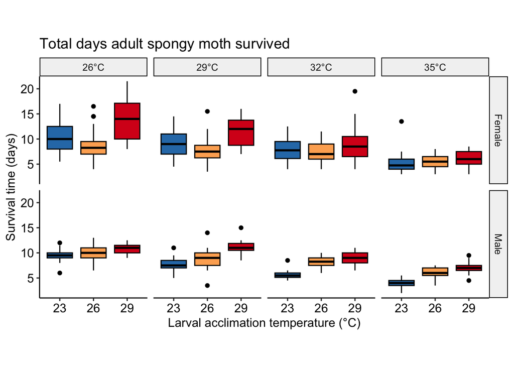

```r
surv_tmps <- c('26°C', '29°C', '32°C', '35°C')
names(surv_tmps) <- c('26', '29', '32', '35')

total_survival_days %>%
  select(sex:survival_temp, survival_time) %>%
  drop_na() %>%
  ggplot(
    aes(
      x = acc_temp %>% as_factor(),
      y = survival_time,
      fill = acc_temp %>% as_factor()
    )
  ) +
  geom_boxplot(color = 'black') +
  scale_fill_manual(values = c('#2c7bb6', '#fdae61', '#d7191c')) +
  labs(
    title = 'Total days adult spongy moth survived',
    x = 'Larval acclimation temperature (°C)',
    y = 'Survival time (days)',
  ) +
  facet_grid(
    sex ~ survival_temp,
    labeller = labeller(survival_temp = surv_tmps)
    ) +
  theme_pubr() +
  theme(
    legend.position = 'none',
    aspect.ratio = 1
    )
```

### 3.3.1 Sample sizes by treatments

```r
total_survival_days %>%
  group_by(sex, acc_temp, survival_temp) %>%
  summarise(N = n()) %>%
  export_table()
```

```
## sex    | acc_temp | survival_temp |  N
## --------------------------------------
## Female |       23 |            26 | 29
## Female |       23 |            29 | 30
## Female |       23 |            32 | 30
## Female |       23 |            35 | 28
## Female |       26 |            26 | 30
## Female |       26 |            29 | 31
## Female |       26 |            32 | 33
## Female |       26 |            35 | 32
## Female |       29 |            26 | 25
## Female |       29 |            29 | 27
## Female |       29 |            32 | 24
## Female |       29 |            35 | 28
## Male   |       23 |            26 | 26
## Male   |       23 |            29 | 26
## Male   |       23 |            32 | 25
## Male   |       23 |            35 | 27
## Male   |       26 |            26 | 30
## Male   |       26 |            29 | 31
## Male   |       26 |            32 | 26
## Male   |       26 |            35 | 26
## Male   |       29 |            26 | 30
## Male   |       29 |            29 | 30
## Male   |       29 |            32 | 30
## Male   |       29 |            35 | 33
```

## 3.4 Survival probability over time

### 3.4.1 Reshaping data for analysis

```r
# dataframe for survival by day for each individual
survival_by_day <-
  total_survival_days %>%
  select(-pupa_mass, -development_time) %>%
  drop_na() %>%
  mutate(half_days = survival_time * 2) %>%  # number of half days alive
  uncount(half_days) %>%
  group_by(id) %>%
  mutate(
    time_d =
      (seq(survival_time[1], length.out = n(), by = -0.5)) - 1  # creating and filling
    ) %>%                                                       # in time data
  arrange(id, time_d) %>%
  filter(time_d >= 0) %>%
  mutate(survival = if_else(time_d == survival_time - 1, 0, 1))

# setting up dataframe for survival analysis
time1 <-  # creating start time column for each survival event
  survival_by_day %>%
  select(-survival_time) %>%
  rename(
    time_1 = time_d,
    survival_1 = survival
    ) %>%
  mutate(row = row_number())

time2 <-  # creating end time column for each survival event
  time1 %>%
  select(-row) %>%
  filter(time_1 != 0) %>%
  mutate(row = row_number()) %>%
  rename(
    time_2 = time_1,
    survival_2 = survival_1
  )

adult_survival <- # merging the start and end time data to create survival analysis data frame
  time1 %>%
  full_join(
    time2,
    by = c('id', 'sex', 'acc_temp', 'survival_temp', 'row')
  ) %>%
  select(-survival_1, -row) %>%
  rename(survival = survival_2) %>%
  drop_na() %>%
  mutate(status = if_else(survival == 1, 0, 1))

# dataframe for plot
adult_survival_fac <-
  adult_survival %>%
  mutate(
    acc_label = case_when(          # labels for larval acclimation temperature
      acc_temp == 23 ~ '23°C',
      acc_temp == 26 ~ '26°C',
      acc_temp == 29 ~ '29°C'
      )
    ) %>%
  mutate(
    surv_label = case_when(         # labels for adult exposure temperature
      survival_temp == 26 ~ '26°C',
      survival_temp == 29 ~ '29°C',
      survival_temp == 32 ~ '32°C',
      survival_temp == 35 ~ '35°C'
    )
  )
```

### 3.4.2 Kaplan-Meier survival curves

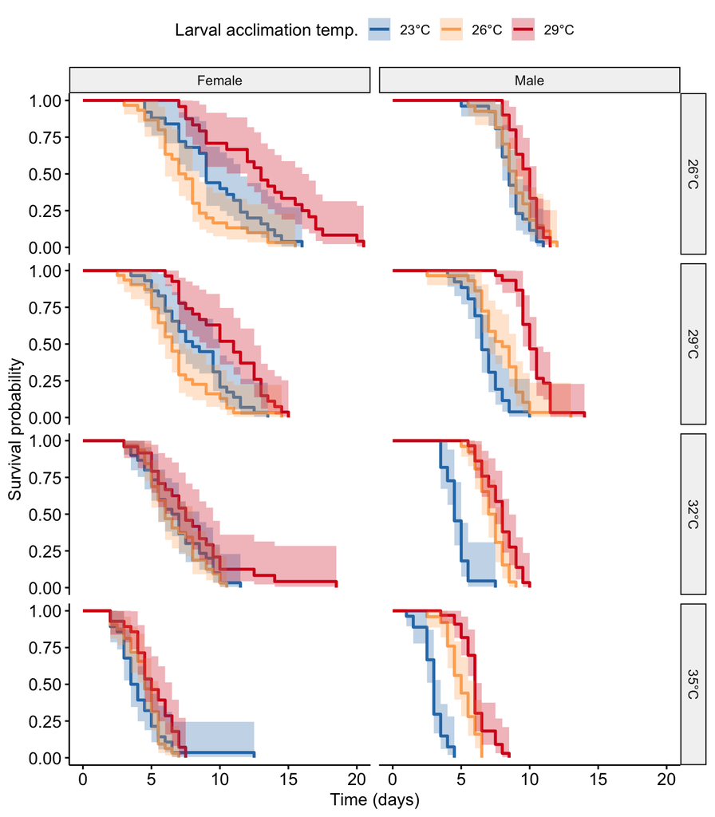

```r
# fitting kaplan-Meier survival curve
ld_fit <-
  survfit(
    Surv(time_1, time_2, status) ~ sex + acc_label + surv_label,
    id = id,
    data = adult_survival_fac
  )

# results from fitted kaplan-Meier curve
ld_summary <-
  ld_fit %>%
  tidy_survfit() %>%
  separate_wider_delim(
    strata,
    delim = ',',
    names = c('sex', 'acc_temp', 'survival_temp')
  ) %>%
  relocate(sex:survival_temp, .before = time)

# plot
ggsurvplot_facet(
  fit = ld_fit,
  data = adult_survival_fac,
  facet.by = c('surv_label', 'sex'),
  short.panel.labs = TRUE,
  palette = c('#2c7bb6', '#fdae61', '#d7191c'),
  conf.int = TRUE,
  ggtheme = theme_pubr()
) +
  labs(fill = 'Larval acclimation temp.',
       color = 'Larval acclimation temp.',
       x = 'Time (days)')
```

# 4 Statistical analysis

We used Cox proportional hazards regression to look more closely at the effects of larval acclimation temperature and sex on the survival probability of male and female adults.

## 4.1 Cox proportional hazards model

To find the best model for analyzing our data we used Akaike Information Criteria (AICc) to compare 6 different candidate models that included sex and/or larval acclimation, adult exposure, and both sex-by-temperature interactions

### 4.1.1 Model selection by AICc

```r
ld_cox1 <-
  coxph(
    Surv(time_1, time_2, status) ~ sex,
    data = adult_survival
    )

ld_cox2 <-
  coxph(
    Surv(time_1, time_2, status) ~ sex + survival_temp,
    data = adult_survival
    )

ld_cox3 <-
  coxph(
    Surv(time_1, time_2, status) ~ sex + survival_temp + acc_temp,
    data = adult_survival
    )

ld_cox4 <-
  coxph(
    Surv(time_1, time_2, status) ~ sex + acc_temp + survival_temp + sex:acc_temp,
    data = adult_survival
    )

ld_cox5 <-
  coxph(
    Surv(time_1, time_2, status) ~ sex + acc_temp + survival_temp + sex:survival_temp,
    data = adult_survival
    )

ld_cox6 <-
  coxph(
    Surv(time_1, time_2, status) ~ sex + acc_temp + survival_temp + sex:acc_temp +
      sex:survival_temp,
    data = adult_survival
    )
best_model <-
  model.sel(
    ld_cox1,
    ld_cox2,
    ld_cox3,
    ld_cox4,
    ld_cox5,
    ld_cox6
    )

best_model
```

```
## Model selection table
##         (Int) sex srv_tmp acc_tmp acc_tmp:sex sex:srv_tmp df    logLik   AICc
## ld_cox4     +   +  0.2748 -0.0940           +              4 -3488.382 6984.8
## ld_cox6     +   +  0.2728 -0.0941           +           +  5 -3488.369 6986.8
## ld_cox3     +   +  0.2598 -0.1611                          3 -3499.527 7005.1
## ld_cox5     +   +  0.2657 -0.1601                       +  4 -3499.421 7006.9
## ld_cox2     +   +  0.2401                                  2 -3547.748 7099.5
## ld_cox1     +   +                                          1 -3691.590 7385.2
##          delta weight
## ld_cox4   0.00  0.732
## ld_cox6   2.00  0.268
## ld_cox3  20.26  0.000
## ld_cox5  22.08  0.000
## ld_cox2 114.69  0.000
## ld_cox1 400.36  0.000
## Models ranked by AICc(x)
```

The AICc rankings of our models show that the top ranked model included the main effects and a sex-by-larval acclimation temperature interaction.

### 4.1.2 Model summary

```r
ld_cox4 %>%
  tidy(exponentiate = TRUE, conf.int = TRUE) %>%
  rename(hazard.ratio = estimate) %>%
  format_table() %>%
  export_table()
```

```
## term             | hazard.ratio | std.error | statistic | p.value |        conf.int
## -----------------------------------------------------------------------------------
## sexMale          |        90.51 |      0.85 |      5.28 |  < .001 | [16.98, 482.28]
## acc_temp         |         0.91 |      0.02 |     -4.40 |  < .001 | [ 0.87,   0.95]
## survival_temp    |         1.32 |      0.01 |     18.51 |  < .001 | [ 1.28,   1.36]
## sexMale:acc_temp |         0.86 |      0.03 |     -4.74 |  < .001 | [ 0.80,   0.91]
```

Hazard ratios for the adult exposure temperature and sex indicate that likelihood of adult survival decreases significantly as temperature increases (-32% for every 1°C increase) and that males were 90.5 times more likely to experience lower adult survival relative to females. While this model indicates lower survival for adult males, the sex-by-larval acclimation hazard ratio indicates that warm temperature acclimation during the larval and pupa stages can significantly improve adult survival for males when exposed to supraoptimal temperatures as an adult (+14% for every 1°C increase).

### 4.1.3 Checking linearity assumption

```r
cox_resid <-
  tibble(
    martingale_res = resid(ld_cox4, type = 'martingale'),
    acc_temp = adult_survival$acc_temp,
    survival_temp = adult_survival$survival_temp
  )
```

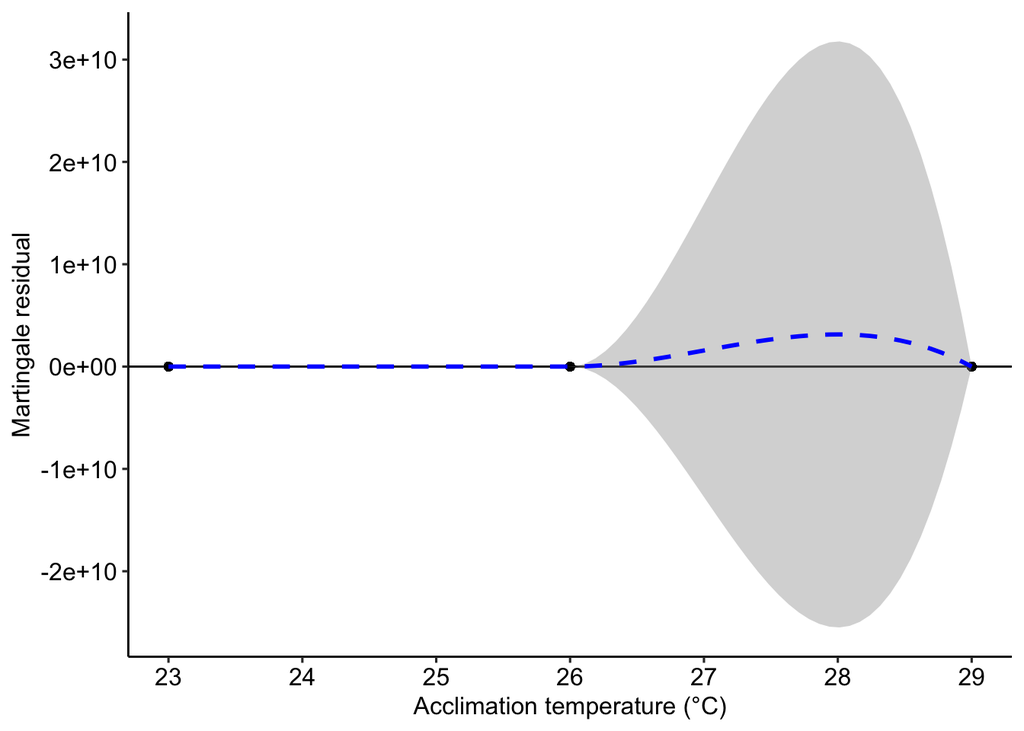

```r
cox_resid %>%
  ggplot(
    aes(
      x = acc_temp,
      y = martingale_res
    )
  ) +
  geom_point() +
  geom_hline(yintercept = 0) +
  geom_smooth(
    color = 'blue',
    method = 'loess',
    linetype = 'dashed'
  ) +
  labs(
    x = 'Acclimation temperature (°C)',
    y = 'Martingale residual'
  ) +
  scale_x_continuous(
    breaks = seq(23, 29, 1),
    limits = c(23,29)
  ) +
  theme_pubr()
```

### 4.1.4 Checking proportional hazards assumption

Model assumes that the hazards between individuals have the same proportion at all times. Thus the model assumes that effect of each predictor remains constant with time.

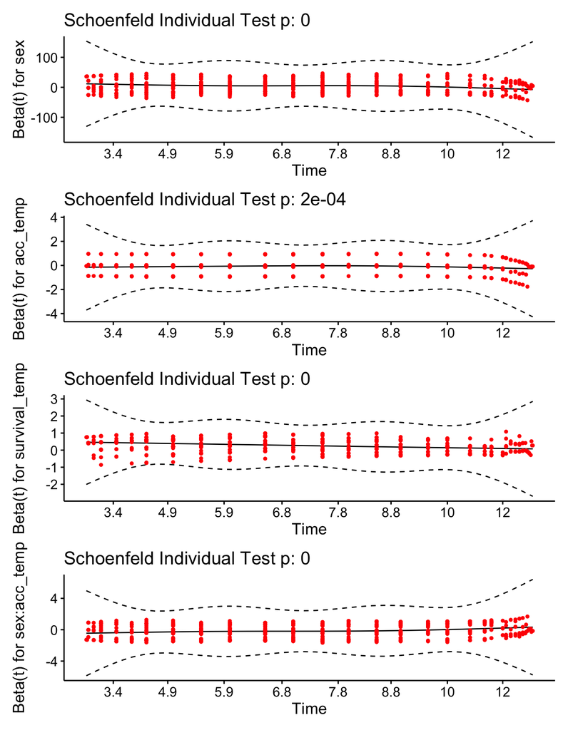

```r
ph_plots <-
  ld_cox4 %>%
  cox.zph() %>%
  ggcoxzph()

ph_plots[[1]] +
  ph_plots[[2]] +
  ph_plots[[3]] +
  ph_plots[[4]] +
  plot_layout(ncol = 1)
```

While the Schoenfeld tests are significant, the plots indicate this assumption was not violated.

### 4.1.5 Plot of acclimation effect

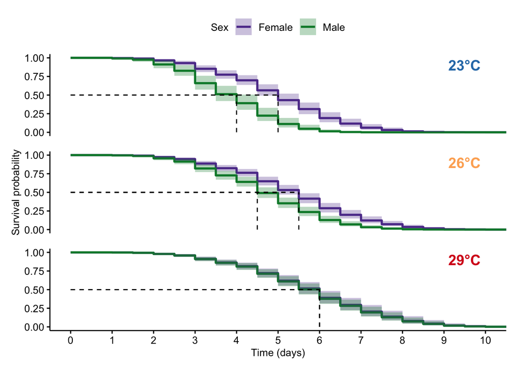

```r
sex_23C <-
  with(
    adult_survival,
    data.frame(
      sex = c('Female', 'Male'),
      acc_temp = c(23, 23),
      survival_temp = c(35, 35)
    )
  )

sex_26C <-
  with(
    adult_survival,
    data.frame(
      sex = c('Female', 'Male'),
      acc_temp = c(26, 26),
      survival_temp = c(35, 35)
    )
  )

sex_29C <-
  with(
    adult_survival,
    data.frame(
      sex = c('Female', 'Male'),
      acc_temp = c(29, 29),
      survival_temp = c(35, 35)
    )
  )

fit_23C <- survfit(ld_cox4, newdata = sex_23C)
fit_26C <- survfit(ld_cox4, newdata = sex_26C)
fit_29C <- survfit(ld_cox4, newdata = sex_29C)

ggsurv_23C <-
  ggsurvplot(
    fit = fit_23C,
    data = sex_23C,
    conf.int = TRUE,
    surv.median.line = 'hv',
    censor = FALSE,
    palette = c('#5e3c99', '#008837'),
    xlim = c(0, 10),
    break.x.by = 1,
    ggtheme = theme_pubr(),
    legend = 'top',
    legend.title = 'Sex',
    legend.labs = c('Female', 'Male')
  )

ggsurv_26C <-
  ggsurvplot(
    fit = fit_26C,
    data = sex_26C,
    conf.int = TRUE,
    surv.median.line = 'hv',
    censor = FALSE,
    palette = c('#5e3c99', '#008837'),
    xlim = c(0, 10),
    break.x.by = 1,
    ggtheme = theme_pubr(),
    legend = 'none',
  )

ggsurv_29C <-
  ggsurvplot(
    fit = fit_29C,
    data = sex_29C,
    conf.int = TRUE,
    surv.median.line = 'hv',
    censor = FALSE,
    palette = c('#5e3c99', '#008837'),
    xlim = c(0, 10),
    break.x.by = 1,
    ggtheme = theme_pubr(),
    legend = 'none'
  )

plot_23C <-
  ggsurv_23C$plot +
  annotate(
    geom = 'text',
    x = 9.5,
    y = 0.9,
    label = '23°C',
    fontface = 'bold',
    color = '#2c7bb6',
    size = 5
  ) +
  theme(
    axis.line.x = element_blank(),
    axis.ticks.x = element_blank(),
    axis.text.x = element_blank(),
    axis.title = element_blank(),
    axis.text = element_text(size = 10),
    legend.title = element_text(size = 10),
    legend.text = element_text(size = 10)
  )

plot_26C <-
  ggsurv_26C$plot +
  annotate(
    geom = 'text',
    x = 9.5,
    y = 0.9,
    label = '26°C',
    fontface = 'bold',
    color = '#fdae61',
    size = 5
  ) +
  theme(
    axis.line.x = element_blank(),
    axis.ticks.x = element_blank(),
    axis.text.x = element_blank(),
    axis.title.x = element_blank(),
    axis.text = element_text(size = 10),
    axis.title.y = element_text(size = 10)
  )

plot_29C <-
  ggsurv_29C$plot +
  labs(x = 'Time (days)') +
  annotate(
    geom = 'text',
    x = 9.5,
    y = 0.9,
    label = '29°C',
    fontface = 'bold',
    color = '#d7191c',
    size = 5
  ) +
  theme(
    axis.title.y = element_blank(),
    axis.text = element_text(size = 10),
    axis.title = element_text(size = 10)
    )

  plot_23C /
  plot_26C /
  plot_29C
```

# 5 Conclusion